# Risk Factor Analysis

## Outcome Variable

**Outcome Variable:** whz

## Predictor Variables

**Intervention Variable:** hdlvry

**Adjustment Set:**

- arm
- sex
- W_mage
- meducyrs
- feducyrs
- hhwealth_quart
- single
- W_nrooms
- brthmon
- W_parity
- impsan
- delta_W_mage
- delta_meducyrs
- delta_feducyrs
- delta_hhwealth_quart
- delta_single
- delta_W_nrooms
- delta_brthmon
- delta_W_parity
- delta_impsan

## Stratifying Variables

The analysis was stratified on these variable(s):

- agecat
- studyid
- country

## Data Summary

| agecat | studyid | country | hdlvry | n_cell | n |
| --- | --- | --- | --- | --- | --- |
| Birth | CMC-V-BCS-2002 | INDIA | 0 | 86 | 86 |
| Birth | CMC-V-BCS-2002 | INDIA | 1 | 0 | 86 |
| Birth | COHORTS | INDIA | 0 | 2763 | 4389 |
| Birth | COHORTS | INDIA | 1 | 1626 | 4389 |
| Birth | EE | PAKISTAN | 0 | 120 | 175 |
| Birth | EE | PAKISTAN | 1 | 55 | 175 |
| Birth | GMS-Nepal | NEPAL | 0 | 143 | 596 |
| Birth | GMS-Nepal | NEPAL | 1 | 453 | 596 |
| Birth | IRC | INDIA | 0 | 337 | 343 |
| Birth | IRC | INDIA | 1 | 6 | 343 |
| Birth | JiVitA-3 | BANGLADESH | 0 | 27 | 292 |
| Birth | JiVitA-3 | BANGLADESH | 1 | 265 | 292 |
| Birth | JiVitA-4 | BANGLADESH | 0 | 500 | 2384 |
| Birth | JiVitA-4 | BANGLADESH | 1 | 1884 | 2384 |
| Birth | NIH-Crypto | BANGLADESH | 0 | 548 | 707 |
| Birth | NIH-Crypto | BANGLADESH | 1 | 159 | 707 |
| Birth | PROVIDE | BANGLADESH | 0 | 387 | 532 |
| Birth | PROVIDE | BANGLADESH | 1 | 145 | 532 |
| Birth | SAS-CompFeed | INDIA | 0 | 108 | 957 |
| Birth | SAS-CompFeed | INDIA | 1 | 849 | 957 |
| 6 months | CMC-V-BCS-2002 | INDIA | 0 | 357 | 365 |
| 6 months | CMC-V-BCS-2002 | INDIA | 1 | 8 | 365 |
| 6 months | COHORTS | INDIA | 0 | 2896 | 4694 |
| 6 months | COHORTS | INDIA | 1 | 1798 | 4694 |
| 6 months | EE | PAKISTAN | 0 | 252 | 373 |
| 6 months | EE | PAKISTAN | 1 | 121 | 373 |
| 6 months | GMS-Nepal | NEPAL | 0 | 129 | 528 |
| 6 months | GMS-Nepal | NEPAL | 1 | 399 | 528 |
| 6 months | IRC | INDIA | 0 | 400 | 408 |
| 6 months | IRC | INDIA | 1 | 8 | 408 |
| 6 months | JiVitA-3 | BANGLADESH | 0 | 39 | 334 |
| 6 months | JiVitA-3 | BANGLADESH | 1 | 295 | 334 |
| 6 months | JiVitA-4 | BANGLADESH | 0 | 1082 | 4042 |
| 6 months | JiVitA-4 | BANGLADESH | 1 | 2960 | 4042 |
| 6 months | NIH-Crypto | BANGLADESH | 0 | 554 | 715 |
| 6 months | NIH-Crypto | BANGLADESH | 1 | 161 | 715 |
| 6 months | PROVIDE | BANGLADESH | 0 | 450 | 603 |
| 6 months | PROVIDE | BANGLADESH | 1 | 153 | 603 |
| 6 months | SAS-CompFeed | INDIA | 0 | 147 | 1088 |
| 6 months | SAS-CompFeed | INDIA | 1 | 941 | 1088 |
| 6 months | SAS-FoodSuppl | INDIA | 0 | 76 | 380 |
| 6 months | SAS-FoodSuppl | INDIA | 1 | 304 | 380 |
| 6 months | TanzaniaChild2 | TANZANIA, UNITED REPUBLIC OF | 0 | 1888 | 1920 |
| 6 months | TanzaniaChild2 | TANZANIA, UNITED REPUBLIC OF | 1 | 32 | 1920 |
| 24 months | CMC-V-BCS-2002 | INDIA | 0 | 361 | 369 |
| 24 months | CMC-V-BCS-2002 | INDIA | 1 | 8 | 369 |
| 24 months | COHORTS | INDIA | 0 | 2214 | 3533 |
| 24 months | COHORTS | INDIA | 1 | 1319 | 3533 |
| 24 months | EE | PAKISTAN | 0 | 112 | 167 |
| 24 months | EE | PAKISTAN | 1 | 55 | 167 |
| 24 months | GMS-Nepal | NEPAL | 0 | 118 | 455 |
| 24 months | GMS-Nepal | NEPAL | 1 | 337 | 455 |
| 24 months | IRC | INDIA | 0 | 401 | 409 |
| 24 months | IRC | INDIA | 1 | 8 | 409 |
| 24 months | JiVitA-3 | BANGLADESH | 0 | 34 | 289 |
| 24 months | JiVitA-3 | BANGLADESH | 1 | 255 | 289 |
| 24 months | JiVitA-4 | BANGLADESH | 0 | 1032 | 3993 |
| 24 months | JiVitA-4 | BANGLADESH | 1 | 2961 | 3993 |
| 24 months | NIH-Crypto | BANGLADESH | 0 | 391 | 514 |
| 24 months | NIH-Crypto | BANGLADESH | 1 | 123 | 514 |
| 24 months | PROVIDE | BANGLADESH | 0 | 433 | 579 |
| 24 months | PROVIDE | BANGLADESH | 1 | 146 | 579 |
| 24 months | TanzaniaChild2 | TANZANIA, UNITED REPUBLIC OF | 0 | 6 | 6 |
| 24 months | TanzaniaChild2 | TANZANIA, UNITED REPUBLIC OF | 1 | 0 | 6 |

The following strata were considered:

- agecat: 24 months, studyid: CMC-V-BCS-2002, country: INDIA
- agecat: 24 months, studyid: COHORTS, country: INDIA
- agecat: 24 months, studyid: EE, country: PAKISTAN
- agecat: 24 months, studyid: GMS-Nepal, country: NEPAL
- agecat: 24 months, studyid: IRC, country: INDIA
- agecat: 24 months, studyid: JiVitA-3, country: BANGLADESH
- agecat: 24 months, studyid: JiVitA-4, country: BANGLADESH
- agecat: 24 months, studyid: NIH-Crypto, country: BANGLADESH
- agecat: 24 months, studyid: PROVIDE, country: BANGLADESH
- agecat: 24 months, studyid: TanzaniaChild2, country: TANZANIA, UNITED REPUBLIC OF
- agecat: 6 months, studyid: CMC-V-BCS-2002, country: INDIA
- agecat: 6 months, studyid: COHORTS, country: INDIA
- agecat: 6 months, studyid: EE, country: PAKISTAN
- agecat: 6 months, studyid: GMS-Nepal, country: NEPAL
- agecat: 6 months, studyid: IRC, country: INDIA
- agecat: 6 months, studyid: JiVitA-3, country: BANGLADESH
- agecat: 6 months, studyid: JiVitA-4, country: BANGLADESH
- agecat: 6 months, studyid: NIH-Crypto, country: BANGLADESH
- agecat: 6 months, studyid: PROVIDE, country: BANGLADESH
- agecat: 6 months, studyid: SAS-CompFeed, country: INDIA
- agecat: 6 months, studyid: SAS-FoodSuppl, country: INDIA
- agecat: 6 months, studyid: TanzaniaChild2, country: TANZANIA, UNITED REPUBLIC OF
- agecat: Birth, studyid: CMC-V-BCS-2002, country: INDIA
- agecat: Birth, studyid: COHORTS, country: INDIA
- agecat: Birth, studyid: EE, country: PAKISTAN
- agecat: Birth, studyid: GMS-Nepal, country: NEPAL
- agecat: Birth, studyid: IRC, country: INDIA
- agecat: Birth, studyid: JiVitA-3, country: BANGLADESH
- agecat: Birth, studyid: JiVitA-4, country: BANGLADESH
- agecat: Birth, studyid: NIH-Crypto, country: BANGLADESH
- agecat: Birth, studyid: PROVIDE, country: BANGLADESH
- agecat: Birth, studyid: SAS-CompFeed, country: INDIA

### Dropped Strata

Some strata were dropped due to rare outcomes:

- agecat: Birth, studyid: CMC-V-BCS-2002, country: INDIA
- agecat: 24 months, studyid: TanzaniaChild2, country: TANZANIA, UNITED REPUBLIC OF

## Methods Detail

We’re interested in the causal parameters $E[Y_a]$ for all values of $a \in \mathcal{A}$. These parameters represent the mean outcome if, possibly contrary to fact, we intervened to set all units to have $A=a$. Under the randomization and positivity assumptions, these are identified by the statistical parameters $\psi_a=E_W[E_{Y|A,W}(Y|A=a,W)]$. In addition, we’re interested in the mean of $Y$, $E[Y]$ under no intervention (the observed mean). We will estimate these parameters by using SuperLearner to fit the relevant likelihood factors – $E_{Y|A,W}(Y|A=a,W)$ and $p(A=a|W)$, and then updating our likelihood fit using a joint TMLE.

For unadjusted analyses ($W=\{\}$), initial likelihoods were estimated using Lrnr_glm to estimate the simple $E(Y|A)$ and Lrnr_mean to estimate $p(A)$. For adjusted analyses, a small library containing Lrnr_glmnet, Lrnr_xgboost, and Lrnr_mean was used.

Having estimated these parameters, we will then use the delta method to estimate relative risks and attributable risks relative to a prespecified baseline level of $A$.

# Results Detail

## Results Plots

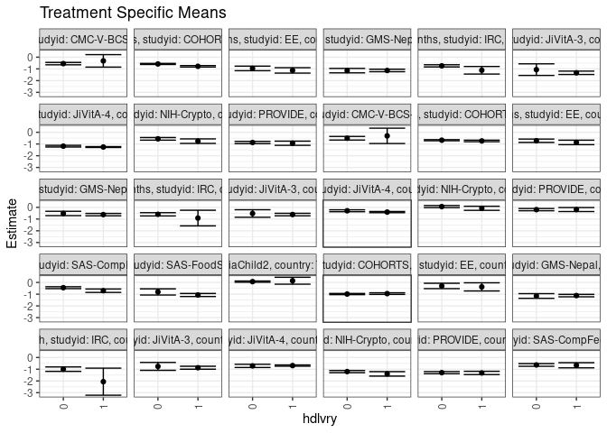

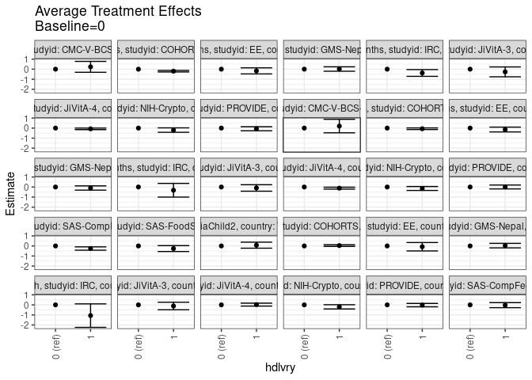

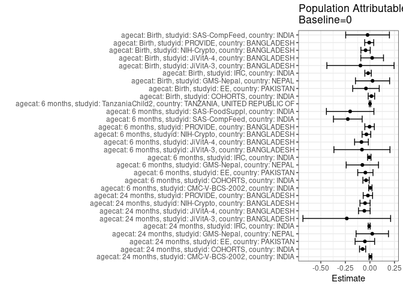

## Results Table

### Parameter: TSM

| agecat | studyid | country | intervention_level | baseline_level | estimate | ci_lower | ci_upper |
| --- | --- | --- | --- | --- | --- | --- | --- |
| Birth | COHORTS | INDIA | 0 | NA | -0.9910685 | -1.0396996 | -0.9424374 |
| Birth | COHORTS | INDIA | 1 | NA | -0.9542945 | -1.0222689 | -0.8863201 |
| Birth | EE | PAKISTAN | 0 | NA | -0.3007954 | -0.5309745 | -0.0706162 |
| Birth | EE | PAKISTAN | 1 | NA | -0.3790885 | -0.7275050 | -0.0306720 |
| Birth | GMS-Nepal | NEPAL | 0 | NA | -1.1544834 | -1.3539093 | -0.9550574 |
| Birth | GMS-Nepal | NEPAL | 1 | NA | -1.1221131 | -1.2254921 | -1.0187342 |
| Birth | IRC | INDIA | 0 | NA | -0.9918991 | -1.1804921 | -0.8033061 |
| Birth | IRC | INDIA | 1 | NA | -2.0600000 | -3.2141159 | -0.9058841 |
| Birth | JiVitA-3 | BANGLADESH | 0 | NA | -0.7569072 | -1.0932446 | -0.4205698 |
| Birth | JiVitA-3 | BANGLADESH | 1 | NA | -0.8705154 | -0.9958753 | -0.7451555 |
| Birth | JiVitA-4 | BANGLADESH | 0 | NA | -0.7135198 | -0.8498074 | -0.5772322 |
| Birth | JiVitA-4 | BANGLADESH | 1 | NA | -0.6890575 | -0.7440516 | -0.6340634 |
| Birth | NIH-Crypto | BANGLADESH | 0 | NA | -1.1999848 | -1.2936234 | -1.1063462 |
| Birth | NIH-Crypto | BANGLADESH | 1 | NA | -1.3962551 | -1.5855533 | -1.2069568 |
| Birth | PROVIDE | BANGLADESH | 0 | NA | -1.2912979 | -1.3826301 | -1.1999657 |
| Birth | PROVIDE | BANGLADESH | 1 | NA | -1.3155604 | -1.4560514 | -1.1750693 |
| Birth | SAS-CompFeed | INDIA | 0 | NA | -0.6331755 | -0.7465687 | -0.5197823 |
| Birth | SAS-CompFeed | INDIA | 1 | NA | -0.6612605 | -0.8794821 | -0.4430390 |
| 6 months | CMC-V-BCS-2002 | INDIA | 0 | NA | -0.5089262 | -0.6640006 | -0.3538519 |
| 6 months | CMC-V-BCS-2002 | INDIA | 1 | NA | -0.3072917 | -0.9616161 | 0.3470328 |
| 6 months | COHORTS | INDIA | 0 | NA | -0.6765250 | -0.7221292 | -0.6309207 |
| 6 months | COHORTS | INDIA | 1 | NA | -0.7392512 | -0.8059556 | -0.6725469 |
| 6 months | EE | PAKISTAN | 0 | NA | -0.7232854 | -0.8659565 | -0.5806143 |
| 6 months | EE | PAKISTAN | 1 | NA | -0.8657262 | -1.0568325 | -0.6746200 |
| 6 months | GMS-Nepal | NEPAL | 0 | NA | -0.5222701 | -0.7076899 | -0.3368504 |
| 6 months | GMS-Nepal | NEPAL | 1 | NA | -0.6204313 | -0.7213698 | -0.5194928 |
| 6 months | IRC | INDIA | 0 | NA | -0.5926333 | -0.7305001 | -0.4547666 |
| 6 months | IRC | INDIA | 1 | NA | -0.9137500 | -1.5807163 | -0.2467837 |
| 6 months | JiVitA-3 | BANGLADESH | 0 | NA | -0.5235171 | -0.8445361 | -0.2024981 |
| 6 months | JiVitA-3 | BANGLADESH | 1 | NA | -0.6161110 | -0.7230576 | -0.5091644 |
| 6 months | JiVitA-4 | BANGLADESH | 0 | NA | -0.2900923 | -0.3724378 | -0.2077467 |
| 6 months | JiVitA-4 | BANGLADESH | 1 | NA | -0.4036849 | -0.4558173 | -0.3515525 |
| 6 months | NIH-Crypto | BANGLADESH | 0 | NA | 0.0652608 | -0.0241608 | 0.1546824 |
| 6 months | NIH-Crypto | BANGLADESH | 1 | NA | -0.0813732 | -0.2555254 | 0.0927789 |
| 6 months | PROVIDE | BANGLADESH | 0 | NA | -0.1955990 | -0.2910642 | -0.1001338 |
| 6 months | PROVIDE | BANGLADESH | 1 | NA | -0.1890275 | -0.3583821 | -0.0196728 |
| 6 months | SAS-CompFeed | INDIA | 0 | NA | -0.4484212 | -0.5307327 | -0.3661098 |
| 6 months | SAS-CompFeed | INDIA | 1 | NA | -0.7057833 | -0.8527199 | -0.5588466 |
| 6 months | SAS-FoodSuppl | INDIA | 0 | NA | -0.8110515 | -1.0741246 | -0.5479784 |
| 6 months | SAS-FoodSuppl | INDIA | 1 | NA | -1.0726176 | -1.2027628 | -0.9424724 |
| 6 months | TanzaniaChild2 | TANZANIA, UNITED REPUBLIC OF | 0 | NA | 0.0676537 | 0.0126246 | 0.1226828 |
| 6 months | TanzaniaChild2 | TANZANIA, UNITED REPUBLIC OF | 1 | NA | 0.1443575 | -0.1508558 | 0.4395707 |
| 24 months | CMC-V-BCS-2002 | INDIA | 0 | NA | -0.5487673 | -0.6500596 | -0.4474751 |
| 24 months | CMC-V-BCS-2002 | INDIA | 1 | NA | -0.3150000 | -0.8468853 | 0.2168853 |
| 24 months | COHORTS | INDIA | 0 | NA | -0.5776763 | -0.6236271 | -0.5317254 |
| 24 months | COHORTS | INDIA | 1 | NA | -0.7781430 | -0.8397635 | -0.7165225 |
| 24 months | EE | PAKISTAN | 0 | NA | -0.9589763 | -1.1530627 | -0.7648899 |
| 24 months | EE | PAKISTAN | 1 | NA | -1.1277896 | -1.3586768 | -0.8969025 |
| 24 months | GMS-Nepal | NEPAL | 0 | NA | -1.1478762 | -1.3375703 | -0.9581820 |
| 24 months | GMS-Nepal | NEPAL | 1 | NA | -1.1331801 | -1.2396196 | -1.0267406 |
| 24 months | IRC | INDIA | 0 | NA | -0.7384331 | -0.8312559 | -0.6456103 |
| 24 months | IRC | INDIA | 1 | NA | -1.1158333 | -1.4387631 | -0.7929036 |
| 24 months | JiVitA-3 | BANGLADESH | 0 | NA | -1.0633514 | -1.5582541 | -0.5684486 |
| 24 months | JiVitA-3 | BANGLADESH | 1 | NA | -1.3320414 | -1.4748871 | -1.1891957 |
| 24 months | JiVitA-4 | BANGLADESH | 0 | NA | -1.1853662 | -1.2553936 | -1.1153387 |
| 24 months | JiVitA-4 | BANGLADESH | 1 | NA | -1.2591964 | -1.2979405 | -1.2204524 |
| 24 months | NIH-Crypto | BANGLADESH | 0 | NA | -0.5607748 | -0.6712834 | -0.4502661 |
| 24 months | NIH-Crypto | BANGLADESH | 1 | NA | -0.7583215 | -0.9501319 | -0.5665111 |
| 24 months | PROVIDE | BANGLADESH | 0 | NA | -0.8722594 | -0.9679595 | -0.7765592 |
| 24 months | PROVIDE | BANGLADESH | 1 | NA | -0.9352337 | -1.1126783 | -0.7577892 |

### Parameter: E(Y)

| agecat | studyid | country | intervention_level | baseline_level | estimate | ci_lower | ci_upper |
| --- | --- | --- | --- | --- | --- | --- | --- |
| Birth | COHORTS | INDIA | NA | NA | -0.9755867 | -1.0106993 | -0.9404741 |
| Birth | EE | PAKISTAN | NA | NA | -0.3410000 | -0.5302198 | -0.1517802 |
| Birth | GMS-Nepal | NEPAL | NA | NA | -1.1277349 | -1.2174865 | -1.0379833 |
| Birth | IRC | INDIA | NA | NA | -1.0105831 | -1.1973019 | -0.8238643 |
| Birth | JiVitA-3 | BANGLADESH | NA | NA | -0.8532192 | -0.9644938 | -0.7419446 |
| Birth | JiVitA-4 | BANGLADESH | NA | NA | -0.6907341 | -0.7437042 | -0.6377640 |
| Birth | NIH-Crypto | BANGLADESH | NA | NA | -1.2441513 | -1.3281130 | -1.1601897 |
| Birth | PROVIDE | BANGLADESH | NA | NA | -1.2984586 | -1.3752758 | -1.2216415 |
| Birth | SAS-CompFeed | INDIA | NA | NA | -0.6570846 | -0.8496671 | -0.4645022 |
| 6 months | CMC-V-BCS-2002 | INDIA | NA | NA | -0.5045068 | -0.6566169 | -0.3523968 |
| 6 months | COHORTS | INDIA | NA | NA | -0.7160077 | -0.7492815 | -0.6827338 |
| 6 months | EE | PAKISTAN | NA | NA | -0.7695800 | -0.8839306 | -0.6552294 |
| 6 months | GMS-Nepal | NEPAL | NA | NA | -0.5992551 | -0.6878945 | -0.5106156 |
| 6 months | IRC | INDIA | NA | NA | -0.5989297 | -0.7344491 | -0.4634104 |
| 6 months | JiVitA-3 | BANGLADESH | NA | NA | -0.6044910 | -0.7122040 | -0.4967781 |
| 6 months | JiVitA-4 | BANGLADESH | NA | NA | -0.3760651 | -0.4191017 | -0.3330285 |
| 6 months | NIH-Crypto | BANGLADESH | NA | NA | 0.0297622 | -0.0491685 | 0.1086930 |
| 6 months | PROVIDE | BANGLADESH | NA | NA | -0.1990907 | -0.2817968 | -0.1163845 |
| 6 months | SAS-CompFeed | INDIA | NA | NA | -0.6734421 | -0.8121314 | -0.5347528 |
| 6 months | SAS-FoodSuppl | INDIA | NA | NA | -1.0121579 | -1.1280429 | -0.8962729 |
| 6 months | TanzaniaChild2 | TANZANIA, UNITED REPUBLIC OF | NA | NA | 0.0688763 | 0.0147308 | 0.1230218 |
| 24 months | CMC-V-BCS-2002 | INDIA | NA | NA | -0.5436992 | -0.6434110 | -0.4439874 |
| 24 months | COHORTS | INDIA | NA | NA | -0.6520577 | -0.6860033 | -0.6181122 |
| 24 months | EE | PAKISTAN | NA | NA | -1.0103892 | -1.1580613 | -0.8627171 |
| 24 months | GMS-Nepal | NEPAL | NA | NA | -1.1238388 | -1.2161263 | -1.0315513 |
| 24 months | IRC | INDIA | NA | NA | -0.7458150 | -0.8368180 | -0.6548120 |
| 24 months | JiVitA-3 | BANGLADESH | NA | NA | -1.2989273 | -1.4377964 | -1.1600583 |
| 24 months | JiVitA-4 | BANGLADESH | NA | NA | -1.2421463 | -1.2763113 | -1.2079812 |
| 24 months | NIH-Crypto | BANGLADESH | NA | NA | -0.6103502 | -0.7050157 | -0.5156847 |
| 24 months | PROVIDE | BANGLADESH | NA | NA | -0.8928670 | -0.9755153 | -0.8102187 |

### Parameter: ATE

| agecat | studyid | country | intervention_level | baseline_level | estimate | ci_lower | ci_upper |
| --- | --- | --- | --- | --- | --- | --- | --- |
| Birth | COHORTS | INDIA | 0 | 0 | 0.0000000 | 0.0000000 | 0.0000000 |
| Birth | COHORTS | INDIA | 1 | 0 | 0.0367740 | -0.0466360 | 0.1201840 |
| Birth | EE | PAKISTAN | 0 | 0 | 0.0000000 | 0.0000000 | 0.0000000 |
| Birth | EE | PAKISTAN | 1 | 0 | -0.0782932 | -0.4968606 | 0.3402743 |
| Birth | GMS-Nepal | NEPAL | 0 | 0 | 0.0000000 | 0.0000000 | 0.0000000 |
| Birth | GMS-Nepal | NEPAL | 1 | 0 | 0.0323702 | -0.1917823 | 0.2565227 |
| Birth | IRC | INDIA | 0 | 0 | 0.0000000 | 0.0000000 | 0.0000000 |
| Birth | IRC | INDIA | 1 | 0 | -1.0681009 | -2.2375241 | 0.1013224 |
| Birth | JiVitA-3 | BANGLADESH | 0 | 0 | 0.0000000 | 0.0000000 | 0.0000000 |
| Birth | JiVitA-3 | BANGLADESH | 1 | 0 | -0.1136082 | -0.4891456 | 0.2619292 |
| Birth | JiVitA-4 | BANGLADESH | 0 | 0 | 0.0000000 | 0.0000000 | 0.0000000 |
| Birth | JiVitA-4 | BANGLADESH | 1 | 0 | 0.0244623 | -0.1215968 | 0.1705214 |
| Birth | NIH-Crypto | BANGLADESH | 0 | 0 | 0.0000000 | 0.0000000 | 0.0000000 |
| Birth | NIH-Crypto | BANGLADESH | 1 | 0 | -0.1962703 | -0.4078005 | 0.0152600 |
| Birth | PROVIDE | BANGLADESH | 0 | 0 | 0.0000000 | 0.0000000 | 0.0000000 |
| Birth | PROVIDE | BANGLADESH | 1 | 0 | -0.0242624 | -0.1920397 | 0.1435149 |
| Birth | SAS-CompFeed | INDIA | 0 | 0 | 0.0000000 | 0.0000000 | 0.0000000 |
| Birth | SAS-CompFeed | INDIA | 1 | 0 | -0.0280850 | -0.2799825 | 0.2238125 |
| 6 months | CMC-V-BCS-2002 | INDIA | 0 | 0 | 0.0000000 | 0.0000000 | 0.0000000 |
| 6 months | CMC-V-BCS-2002 | INDIA | 1 | 0 | 0.2016346 | -0.4708151 | 0.8740843 |
| 6 months | COHORTS | INDIA | 0 | 0 | 0.0000000 | 0.0000000 | 0.0000000 |
| 6 months | COHORTS | INDIA | 1 | 0 | -0.0627263 | -0.1431526 | 0.0177000 |
| 6 months | EE | PAKISTAN | 0 | 0 | 0.0000000 | 0.0000000 | 0.0000000 |
| 6 months | EE | PAKISTAN | 1 | 0 | -0.1424408 | -0.3810463 | 0.0961647 |
| 6 months | GMS-Nepal | NEPAL | 0 | 0 | 0.0000000 | 0.0000000 | 0.0000000 |
| 6 months | GMS-Nepal | NEPAL | 1 | 0 | -0.0981612 | -0.3095087 | 0.1131864 |
| 6 months | IRC | INDIA | 0 | 0 | 0.0000000 | 0.0000000 | 0.0000000 |
| 6 months | IRC | INDIA | 1 | 0 | -0.3211167 | -1.0021830 | 0.3599496 |
| 6 months | JiVitA-3 | BANGLADESH | 0 | 0 | 0.0000000 | 0.0000000 | 0.0000000 |
| 6 months | JiVitA-3 | BANGLADESH | 1 | 0 | -0.0925939 | -0.4140703 | 0.2288824 |
| 6 months | JiVitA-4 | BANGLADESH | 0 | 0 | 0.0000000 | 0.0000000 | 0.0000000 |
| 6 months | JiVitA-4 | BANGLADESH | 1 | 0 | -0.1135926 | -0.2091063 | -0.0180790 |
| 6 months | NIH-Crypto | BANGLADESH | 0 | 0 | 0.0000000 | 0.0000000 | 0.0000000 |
| 6 months | NIH-Crypto | BANGLADESH | 1 | 0 | -0.1466340 | -0.3428918 | 0.0496238 |
| 6 months | PROVIDE | BANGLADESH | 0 | 0 | 0.0000000 | 0.0000000 | 0.0000000 |
| 6 months | PROVIDE | BANGLADESH | 1 | 0 | 0.0065715 | -0.1876768 | 0.2008198 |
| 6 months | SAS-CompFeed | INDIA | 0 | 0 | 0.0000000 | 0.0000000 | 0.0000000 |
| 6 months | SAS-CompFeed | INDIA | 1 | 0 | -0.2573620 | -0.4212560 | -0.0934681 |
| 6 months | SAS-FoodSuppl | INDIA | 0 | 0 | 0.0000000 | 0.0000000 | 0.0000000 |
| 6 months | SAS-FoodSuppl | INDIA | 1 | 0 | -0.2615661 | -0.5540264 | 0.0308941 |
| 6 months | TanzaniaChild2 | TANZANIA, UNITED REPUBLIC OF | 0 | 0 | 0.0000000 | 0.0000000 | 0.0000000 |
| 6 months | TanzaniaChild2 | TANZANIA, UNITED REPUBLIC OF | 1 | 0 | 0.0767038 | -0.2236673 | 0.3770748 |
| 24 months | CMC-V-BCS-2002 | INDIA | 0 | 0 | 0.0000000 | 0.0000000 | 0.0000000 |
| 24 months | CMC-V-BCS-2002 | INDIA | 1 | 0 | 0.2337673 | -0.3076771 | 0.7752117 |
| 24 months | COHORTS | INDIA | 0 | 0 | 0.0000000 | 0.0000000 | 0.0000000 |
| 24 months | COHORTS | INDIA | 1 | 0 | -0.2004668 | -0.2765415 | -0.1243920 |
| 24 months | EE | PAKISTAN | 0 | 0 | 0.0000000 | 0.0000000 | 0.0000000 |
| 24 months | EE | PAKISTAN | 1 | 0 | -0.1688133 | -0.4708007 | 0.1331742 |
| 24 months | GMS-Nepal | NEPAL | 0 | 0 | 0.0000000 | 0.0000000 | 0.0000000 |
| 24 months | GMS-Nepal | NEPAL | 1 | 0 | 0.0146961 | -0.2054917 | 0.2348838 |
| 24 months | IRC | INDIA | 0 | 0 | 0.0000000 | 0.0000000 | 0.0000000 |
| 24 months | IRC | INDIA | 1 | 0 | -0.3774002 | -0.7134057 | -0.0413948 |
| 24 months | JiVitA-3 | BANGLADESH | 0 | 0 | 0.0000000 | 0.0000000 | 0.0000000 |
| 24 months | JiVitA-3 | BANGLADESH | 1 | 0 | -0.2686900 | -0.7612942 | 0.2239142 |
| 24 months | JiVitA-4 | BANGLADESH | 0 | 0 | 0.0000000 | 0.0000000 | 0.0000000 |
| 24 months | JiVitA-4 | BANGLADESH | 1 | 0 | -0.0738303 | -0.1521499 | 0.0044894 |
| 24 months | NIH-Crypto | BANGLADESH | 0 | 0 | 0.0000000 | 0.0000000 | 0.0000000 |
| 24 months | NIH-Crypto | BANGLADESH | 1 | 0 | -0.1975467 | -0.4184227 | 0.0233293 |
| 24 months | PROVIDE | BANGLADESH | 0 | 0 | 0.0000000 | 0.0000000 | 0.0000000 |
| 24 months | PROVIDE | BANGLADESH | 1 | 0 | -0.0629744 | -0.2629555 | 0.1370068 |

### Parameter: PAR

| agecat | studyid | country | intervention_level | baseline_level | estimate | ci_lower | ci_upper |
| --- | --- | --- | --- | --- | --- | --- | --- |
| Birth | COHORTS | INDIA | 0 | NA | 0.0154818 | -0.0173722 | 0.0483358 |
| Birth | EE | PAKISTAN | 0 | NA | -0.0402046 | -0.1754448 | 0.0950355 |
| Birth | GMS-Nepal | NEPAL | 0 | NA | 0.0267485 | -0.1471364 | 0.2006333 |
| Birth | IRC | INDIA | 0 | NA | -0.0186840 | -0.0514705 | 0.0141025 |
| Birth | JiVitA-3 | BANGLADESH | 0 | NA | -0.0963120 | -0.4385690 | 0.2459450 |
| Birth | JiVitA-4 | BANGLADESH | 0 | NA | 0.0227858 | -0.0927898 | 0.1383613 |
| Birth | NIH-Crypto | BANGLADESH | 0 | NA | -0.0441665 | -0.0917434 | 0.0034103 |
| Birth | PROVIDE | BANGLADESH | 0 | NA | -0.0071607 | -0.0530576 | 0.0387361 |
| Birth | SAS-CompFeed | INDIA | 0 | NA | -0.0239091 | -0.2466022 | 0.1987840 |
| 6 months | CMC-V-BCS-2002 | INDIA | 0 | NA | 0.0044194 | -0.0126632 | 0.0215020 |
| 6 months | COHORTS | INDIA | 0 | NA | -0.0394827 | -0.0715143 | -0.0074511 |
| 6 months | EE | PAKISTAN | 0 | NA | -0.0462946 | -0.1240254 | 0.0314362 |
| 6 months | GMS-Nepal | NEPAL | 0 | NA | -0.0769849 | -0.2414445 | 0.0874746 |
| 6 months | IRC | INDIA | 0 | NA | -0.0062964 | -0.0238639 | 0.0112711 |
| 6 months | JiVitA-3 | BANGLADESH | 0 | NA | -0.0809739 | -0.3663472 | 0.2043994 |
| 6 months | JiVitA-4 | BANGLADESH | 0 | NA | -0.0859728 | -0.1560052 | -0.0159404 |
| 6 months | NIH-Crypto | BANGLADESH | 0 | NA | -0.0354986 | -0.0797925 | 0.0087954 |
| 6 months | PROVIDE | BANGLADESH | 0 | NA | -0.0034917 | -0.0517306 | 0.0447472 |
| 6 months | SAS-CompFeed | INDIA | 0 | NA | -0.2250209 | -0.3713459 | -0.0786958 |
| 6 months | SAS-FoodSuppl | INDIA | 0 | NA | -0.2011064 | -0.4429248 | 0.0407120 |
| 6 months | TanzaniaChild2 | TANZANIA, UNITED REPUBLIC OF | 0 | NA | 0.0012226 | -0.0063257 | 0.0087710 |
| 24 months | CMC-V-BCS-2002 | INDIA | 0 | NA | 0.0050681 | -0.0089078 | 0.0190440 |
| 24 months | COHORTS | INDIA | 0 | NA | -0.0743815 | -0.1057224 | -0.0430406 |
| 24 months | EE | PAKISTAN | 0 | NA | -0.0514129 | -0.1507578 | 0.0479320 |
| 24 months | GMS-Nepal | NEPAL | 0 | NA | 0.0240373 | -0.1409630 | 0.1890377 |
| 24 months | IRC | INDIA | 0 | NA | -0.0073819 | -0.0171941 | 0.0024303 |
| 24 months | JiVitA-3 | BANGLADESH | 0 | NA | -0.2355760 | -0.6820691 | 0.2109171 |
| 24 months | JiVitA-4 | BANGLADESH | 0 | NA | -0.0567801 | -0.1158005 | 0.0022403 |
| 24 months | NIH-Crypto | BANGLADESH | 0 | NA | -0.0495754 | -0.1010946 | 0.0019437 |
| 24 months | PROVIDE | BANGLADESH | 0 | NA | -0.0206076 | -0.0684236 | 0.0272083 |